# Weather in the United States (1996-2023)

by Just Commit (Group number: 17): Olivia Harris, Maxwell Pohlmann, Sarah Stewart, Helen Miller, Andrew Morris, & Adam Laycock

2024-12-02

```r
library(tidyverse)
library(tidymodels)
library(janitor)
library(workflows)
library(parsnip)
library(tidyclust)
library(usmap)
library(gghighlight)
library(knitr)
library(xaringanExtra)
library(doParallel)
library(broom)
library(patchwork)

xaringanExtra::use_panelset()
```

# Research Question

How have storm events changed over time, and what are the personal and monetary effects of these changes?

We chose to investigate this question due to the increasingly dramatic shifts in climate observed in recent years. Many of these changes seem to be significantly impacting the United States, and we wanted to explore those impacts in our data.

# Data

Our data was sourced from the Storm Events Database of the National Oceanic and Atmospheric Administration (NOAA). Individual .csv files were downloaded and compiled using the script found in `data/compile_script`. The NOAA collects data on weather events in the United States. This includes information on event location, 50 variables related to event details (including, notably, time of occurrence and damages), and 10 variables related to event fatalities. In our analysis, we focused on over 1.6 million observations collected between 1996 and 2023.

In our initial cleaning, we notably removed unwanted variables such as event narrative (a multi-sentence description of the event), merged date columns and converted them to date-times with `lubridate`, and added a column for total damage cost (summing crop and property damage). All damage information was converted from a string to a double. The cleaning script can be found in it’s entirety below.

# Load Data

```r
details = read_csv('data/original_data/details_combined.csv')
fatalities = read_csv('data/original_data/fatalities_combined.csv')
```

# Clean Data

```r
# Merge and convert formats of begin-date variables
details <- details %>%
  # Combine date elements
  unite("BEGIN_DATE", BEGIN_YEARMONTH, BEGIN_DAY, sep = "") %>%
  mutate(
    # Convert date to a character for union with time
    BEGIN_DATE = as.character(BEGIN_DATE),
    # Add leading zero if the time is 3 digits
    BEGIN_TIME = case_when(
      BEGIN_TIME < 1000 ~ sprintf("%04d", BEGIN_TIME),
      TRUE ~ as.character(BEGIN_TIME)
    )
  ) %>%
  # Unite date and time into one string
  unite("BEGIN_DT", BEGIN_DATE, BEGIN_TIME, sep = " ") %>%
  mutate(
    # Convert to a datetime
    BEGIN_DT = ymd_hm(BEGIN_DT)
  )

# Merge and convert formats of end-date variables
details <- details %>%
  # Combine date elements
  unite("END_DATE", END_YEARMONTH, END_DAY, sep = "") %>%
  mutate(
    # Convert date to a character for union with time
    END_DATE = as.character(END_DATE),
    # Add leading zero if the time is 3 digits
    END_TIME = case_when(
      END_TIME < 1000 ~ sprintf("%04d", END_TIME),
      TRUE ~ as.character(END_TIME)
    )
  ) %>%
  # Unite date and time into one string
  unite("END_DT", END_DATE, END_TIME, sep = " ") %>%
  mutate(
    # Convert to a datetime
    END_DT = ymd_hm(END_DT)
  )

# Remove unnecessary columns
details <- details %>%
  select(
    -c(YEAR, MONTH_NAME, BEGIN_DATE_TIME, END_DATE_TIME,
       EVENT_NARRATIVE, EPISODE_NARRATIVE
    )
  )

# Rename incorrect column names
details <- details %>%
  rename(
    REGION = STATE,
    REGION_FIPS = STATE_FIPS
  )

# Create duration variable
details <- details %>%
  mutate(
    duration = END_DT - BEGIN_DT
  ) %>%
    mutate(
      duration = as.numeric(duration) / 60
    )

# Change cost suffixes
details <- details %>%
  mutate(
    DAMAGE_PROPERTY = as.numeric(gsub("K", "e+03", gsub("M", "e+06", DAMAGE_PROPERTY))),
    DAMAGE_CROPS = as.numeric(gsub("K", "e+03", gsub("M", "e+06", DAMAGE_CROPS)))
  )

# Create a total damage column using crops and property
details <- details %>%
  mutate(
    DAMAGE_TOTAL = DAMAGE_PROPERTY + DAMAGE_CROPS
  )

# Remove all records pertaining to an incomplete year
details <- details %>%
  filter(
    !year(BEGIN_DT) == '2024'
  )

# Use janitor to convert variable names to snakecase
details <- details %>%
  clean_names()

# Tidy the fatalities DataFrame
fatalities <- fatalities %>%
  select(
    -FAT_TIME, -FATALITY_DATE, -EVENT_YEARMONTH
  ) %>%
    mutate(
      YMD = ymd(paste(FAT_YEARMONTH, FAT_DAY))
    ) %>%
      select(
        -FAT_DAY, -FAT_YEARMONTH
      )

# Remove 2024 records
fatalities <- fatalities %>%
  filter(
    !year(YMD) == '2024'
  )

# Use janitor to convert variables to snakecase
fatalities <- fatalities %>%
  clean_names()

details <- details %>%
  mutate(
    event_type = recode(
      event_type,
      "Hurricane (Typhoon)" = "Hurricane"
    )
  )

#save cleaned data
#write_rds(details, "data/clean_data/details_clean.rds", compress = "gz")
#write_rds(fatalities, "data/clean_data/fatalities_clean.rds")
```

# Load Cleaned Data

```r
details = read_rds('data/clean_data/details_clean.rds')
fatalities = read_rds('data/clean_data/fatalities_clean.rds')
```

# Changes in Storm Event Frequency Over Time

To identify how storm events have changed over time we used a linear regression model attempting to predict the number of storm events per year. We grouped event frequencies by year to balance statistical significance and trend visibility as smaller groups were skewed by outliers, while larger ones (e.g. 5-year periods) lacked sufficient detail to show trends. To do this, we created the object `events_per_year` by summing event frequencies annually and ran the regression: `lm(event_count ~ year, data = events_per_year)`. The results predicted for every one-year increase there will be, on average, an additional 774.2 storm events per year. These results are statistically significant (p < 0.01, R-squared = 0.536) with over half of the variation in `event_count` explained by the variable `year`.

We created similar models using fatalities and damages per year. These models predict that for every additional year, on average, fatalities will increase by 15.3 individuals and damages will increase by $447 million. Both these results have p-values < 0.05 and are statistically significant. However, the R-squared values are low (0.3 for damages and 0.2 for fatalities), indicating there are other factors with a significant influence.

# Regional Exploration

In visualising the total number of weather events, we found that Texas experienced considerably more weather events than any other state. This could potentially be explained by its considerable size.

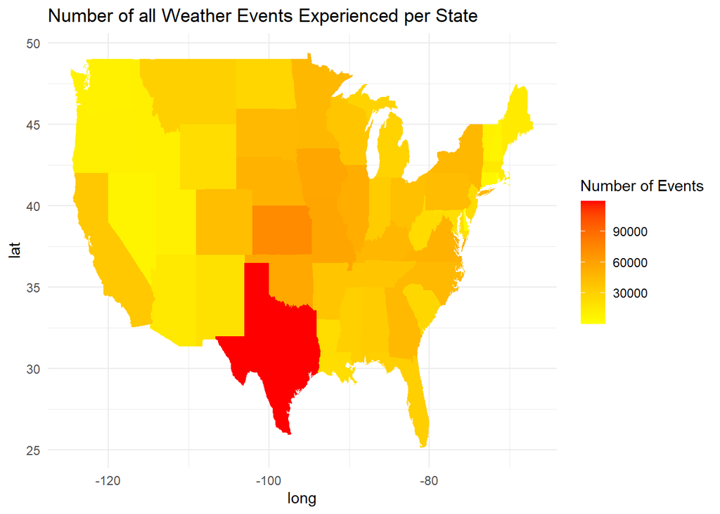

When comparing this data to the total number of fatalities caused by all weather events, we found that, as predicted, Florida, California, and Texas all experienced a high fatality rate. However, Arizona showed an unexpectedly high number of fatalities, though it did not experience as many severe weather events.

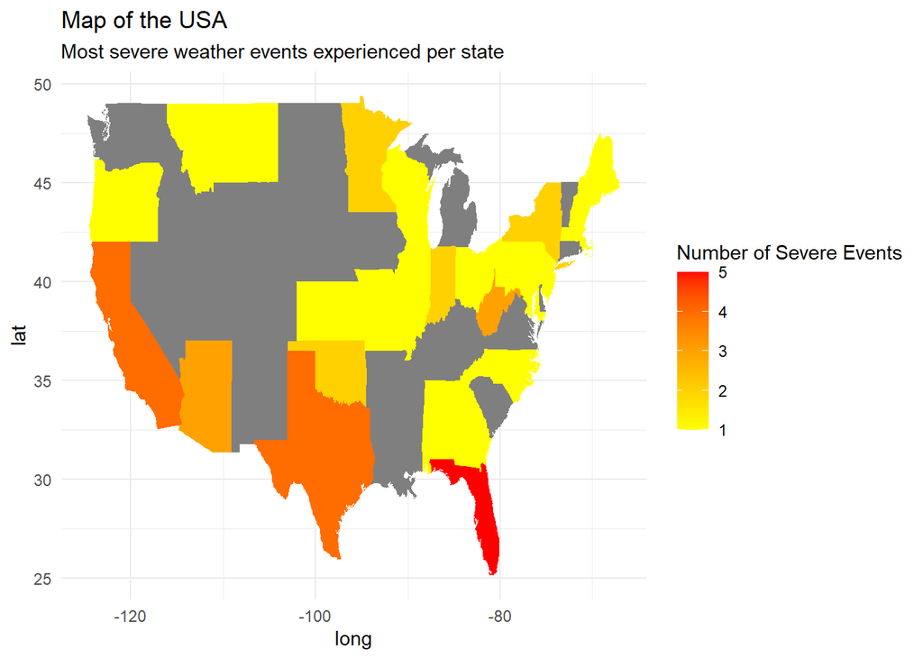

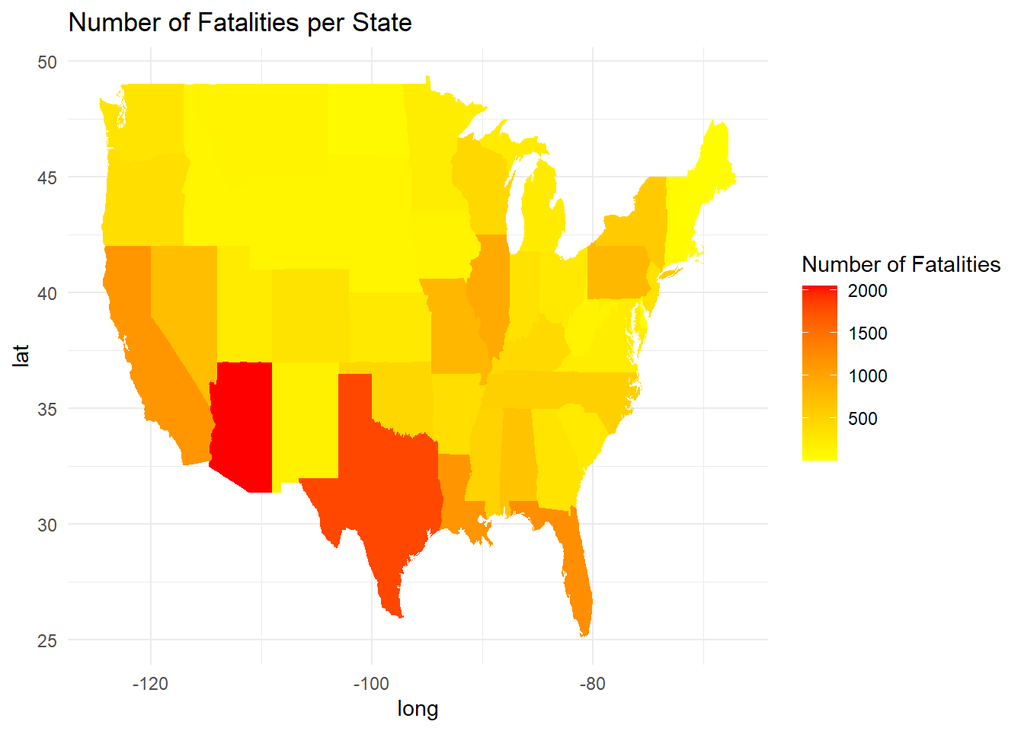

# Damage Makeup by Event Type

When exploring damages by event type, we found that not all highly damaging events caused the same type of damage. Flash floods and tornadoes predominantly caused damage to property, while droughts and freezes disproportionately affected crops.

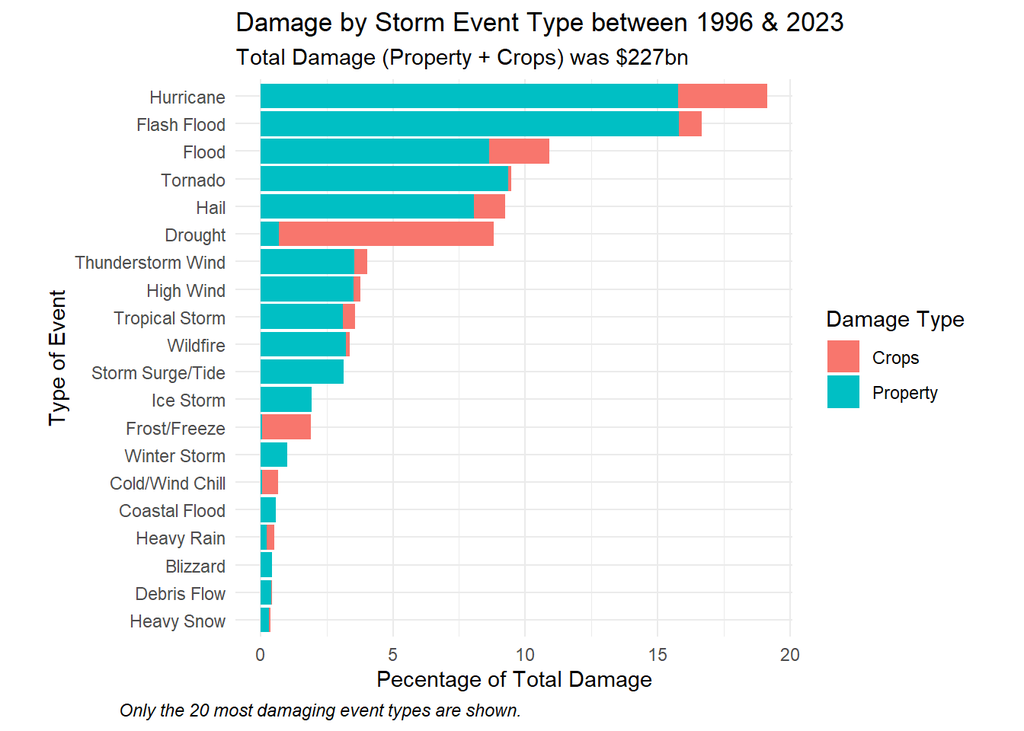

# Event Severity Clustering Using K-means

We were interested in determining if a k-means clustering algorithm could be used to group events. Fatalities and damage were scaled and fed into a k-means model. The optimum number of clusters was determined using an elbow plot and clusters were visualised.

## Elbow Plot

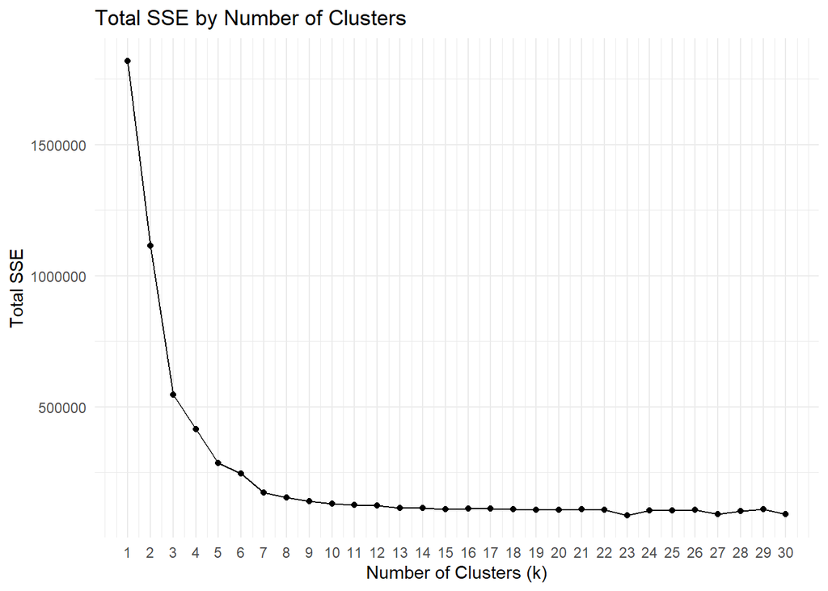

## Scatterplot using Clusters

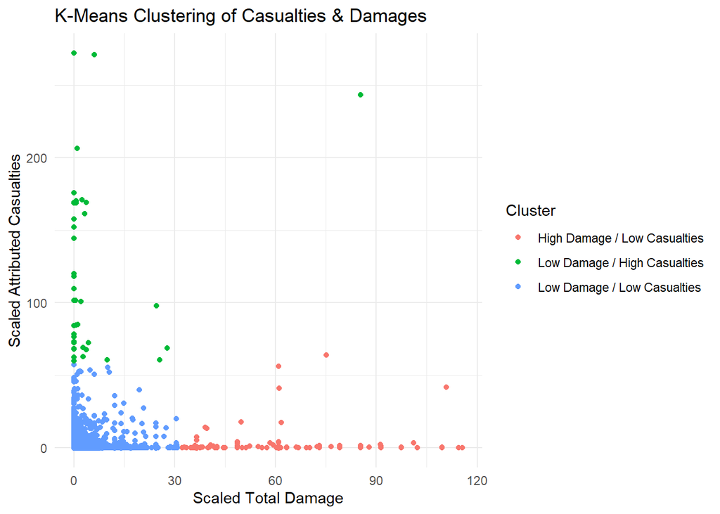

## Tabular Clusters

| Cluster | Total |
| --- | --- |
| Low Damage / Low Casualties | 909757 |
| High Damage / Low Casualties | 173 |
| Low Damage / High Casualties | 43 |

Across the assessed period, the vast majority of storm events fell into the low severity category with a minority in the high damage or high casualty clusters.

# Geospatial Correlation Between Events & Time

## Building the Function

The function below is used to visualise correlation coefficients between event proportions, for a particular event type, per year and time. Only the statistically significant coefficients for each state are shown.

```r
# Define function
map_correlations <- function(event_type) {
  # Defuse argument for dplyr
  event_type_expr <- enquo(event_type)

  # Group by region and year
  total_region_data <- details %>%
    select(
      begin_dt, event_type, region
    ) %>%
      group_by(
        region, year(begin_dt)
      ) %>%
        summarise(
          ov_total = n()
        ) %>%
          rename(
            year = `year(begin_dt)`
          )

  # Evaluate and filter by event type, join to total events
  region_data <- details %>%
    filter(
      event_type == !!event_type_expr
    ) %>%
      select(
        begin_dt, event_type, region
      ) %>%
        group_by(
          region, year(begin_dt)
        ) %>%
          summarise(
            total = n()
          ) %>%
            arrange(
              desc(total)
            ) %>%
              rename(
                year = `year(begin_dt)`
              ) %>%
                inner_join(
                  total_region_data, by=c('region', 'year')
                ) %>%
                  mutate(
                    prop = total / ov_total
                  )

  # Run pearson's rank between time & event proportion
  correlation_data <- region_data %>%
    group_by(
      region
    ) %>%
      summarise(
        # Continue through common, non-fatal errors
        corr_test = list(tryCatch(
          cor.test(
            year,
            prop,
            method = "pearson",
            use = "complete.obs"
          ),
          error = function(e) NULL
        ))
      ) %>%
        # Add correlation and p-values into variables
        mutate(
          corr = sapply(corr_test, function(test) if (!is.null(test)) test$estimate else NA),
          p_value = sapply(corr_test, function(test) if (!is.null(test)) test$p.value else NA)
        ) %>%
          # Remove NA values and statistically insignificant results
          filter(
            !is.na(corr) & !is.na(p_value) & p_value <= 0.05
          ) %>%
            select(
              region, corr, p_value
            ) %>%
              mutate(
                event_type = event_type
              )

  # Build a map of the US
  map_data <- usmap::us_map(regions = "states")

  # Mutate map_data to have parity with correlation data
  map_data <- map_data %>%
    mutate(
      full = tolower(full)
    ) %>%
      rename(
        region = full
      )

  # Alter correlation region data
  correlation_data <- correlation_data %>%
    mutate(
      region = tolower(region)
    )

  # Join correlation and map data
  data <- left_join(map_data, correlation_data, by='region')

  # Build the map showing correlations
  plot_usmap(
    data=data,
    values='corr'
  ) +
  scale_fill_continuous(name = "Correlation \nCoefficient") +
  theme(legend.position = "right") +
  labs(
    title=paste('Correlations Between Year &', event_type, 'Events as a Proportion of Total State Events'
          ),
    subtitle = 'Only statistically significant (p<=0.05) correlation coefficients are shown'
  )
}
```

## Using the Function

### Thunderstorm Wind

#### Thunderstorm Wind Events

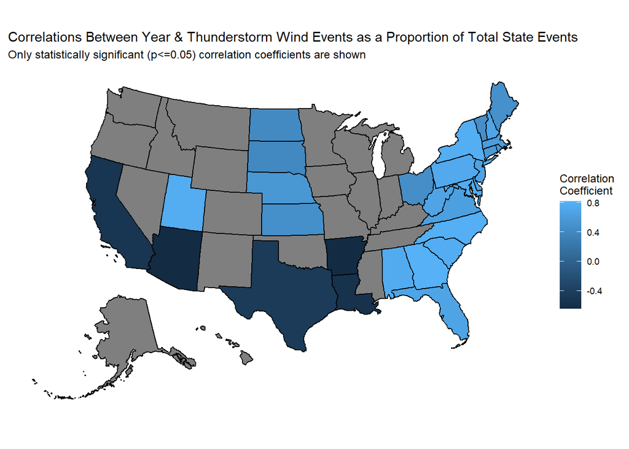

### Droughts

#### Drought Events

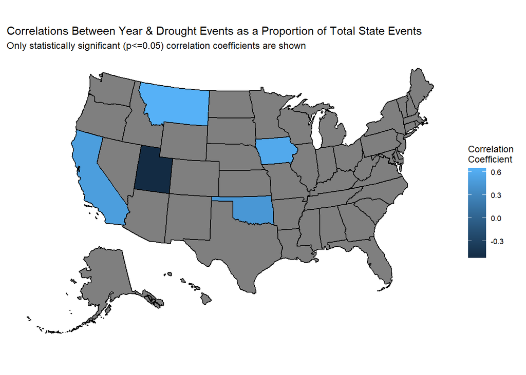

### Hurricanes

#### Hurricane Events

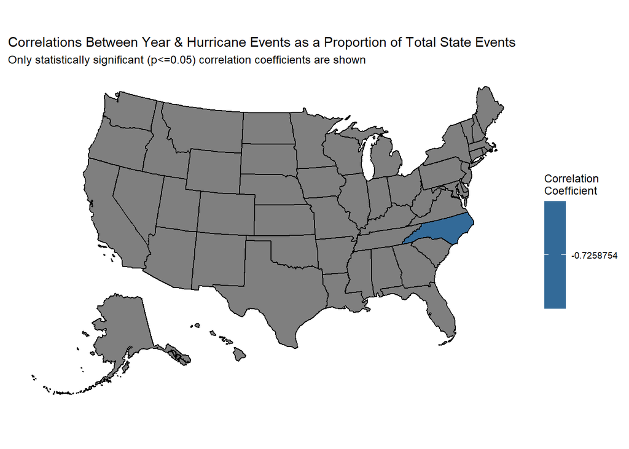

These plots highlight a key limitation with this script: rarer events are much harder to track and predict through time. As a result, many potential correlations for these events, such as hurricanes or droughts, cannot be shown due to statistical insignificance owing to a smaller sample size.

# Deadly Storm Predictor

We also wanted to assess whether it was possible to predict if a storm would cause fatalities, using only information about the event that could be known beforehand. We used a logistic regression model with the input variables of `begin_dt`, `region`, and `event_type`.

## Assessing Model Fit

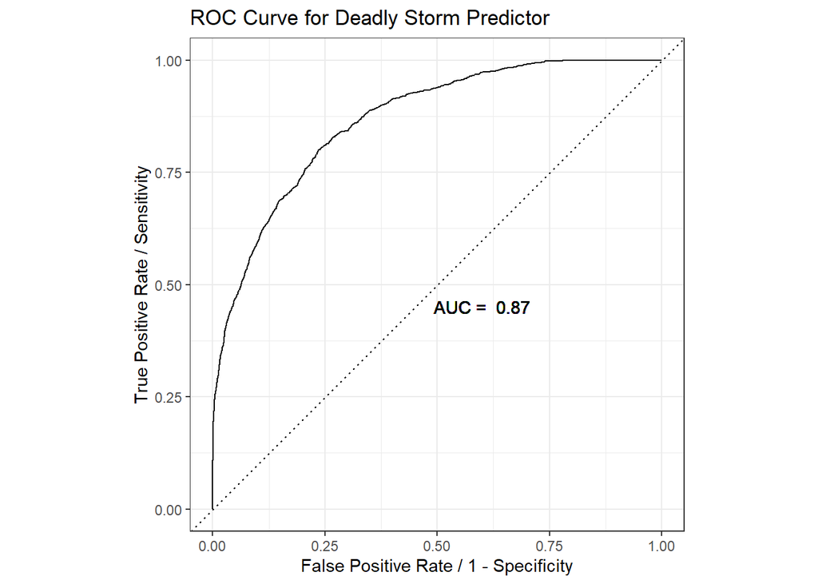

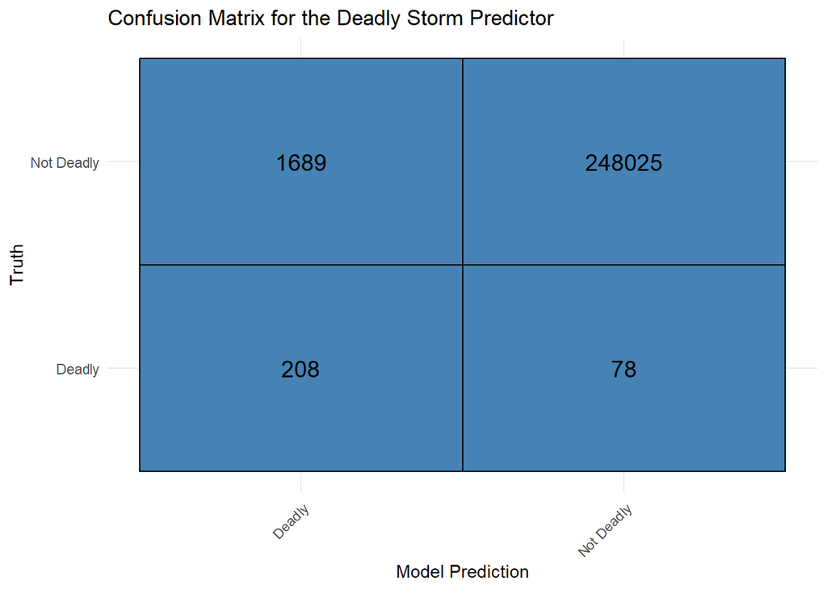

| Result | Percentage |
| --- | --- |
| Correct | 99.2932 |
| Incorrect | 0.7068 |

Overall, the model metrics appeared to indicate that the fit was appropriate and was able to generalise when encountering new events.

# Event Type Averages

We split event types into two categories: more damaging/deadly and less damaging/deadly (relative to the mean). This was used to assess whether increased damages and fatalities over time were reflected equally in both severe and less severe storm events.

We used mean impact for the analysis of changes in fatalities and damages due to the possibility of stronger storms overall or greater storm frequency over time.

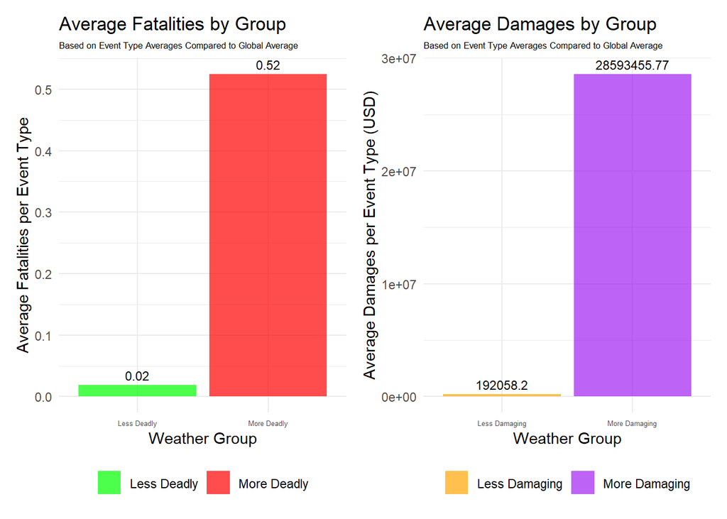

This process was repeated for 1996–7 and 2022–3, using two-year periods to minimise the impact of outliers.

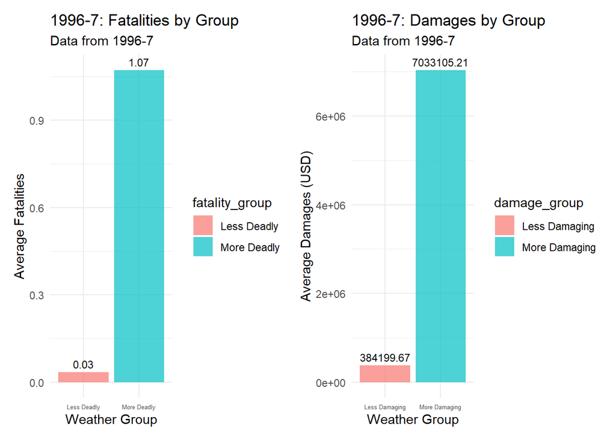

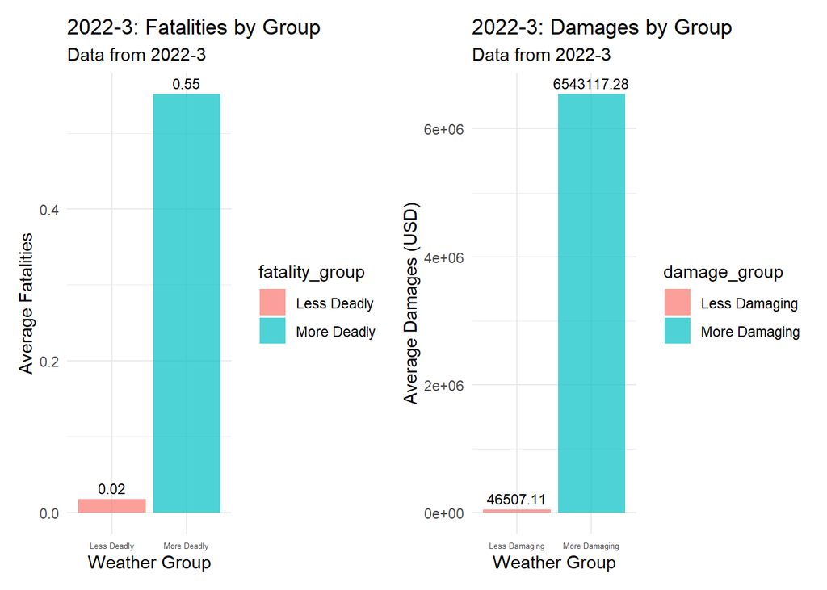

We found that the averages of damages and fatalities decreased from 1996–7 to 2022–3. By creating and joining the year groups, we were able to produce a table showing the percent and absolute change in the overall average of each period. Finally, percent change was calculated for the more damaging/deadly and less damaging/deadly categories.

| metric | avg_1996_7 | avg_2022_3 | absolute_change | percent_change |
| --- | --- | --- | --- | --- |
| Fatalities | 1.174728e-01 | 1.162609e-01 | -1.211900e-03 | -1.031671 |
| Damages | 1.713981e+06 | 7.683527e+05 | -9.456281e+05 | -55.171452 |

```r
# Laying it all out
Percent_change_less_fatalities
```

```
## [1] -33.33333
```

```r
Percent_change_more_fatalities
```

```
## [1] -48.59813
```

```r
Percent_change_less_damages
```

```
## [1] -87.89507
```

```r
Percent_change_more_damages
```

```
## [1] -6.966879
```

While total damage and fatalities increased, the average impact per event declined. This suggests that increased storm frequency has had a larger impact on people and property than storm strength. However, we should note that this dataset had no variable representing infrastructure strength, which could confound our results.

# Event Proportions and ENSO Status

We were also interested in if the impact of El Niño Southern Oscillation (ENSO) was visible in our data. To simplify this investigation, irrelevant variables were removed from the `details_clean` data set. Then, using data from NOAA and NASA, a column displaying the ENSO status of each year was added and the resulting data frame was saved as `details_enso`. Finally, a table of expected and observed events grouped by ENSO status was produced for initial analysis. `exp_prop` acts as a null hypothesis– assuming ENSO status has no impact on event frequency.

| enso_status | obs_count | obs_prop | exp_prop |
| --- | --- | --- | --- |
| el_nino | 356995 | 0.2179159 | 0.2142857 |
| la_nina | 444449 | 0.2712993 | 0.2500000 |
| neutral | 836780 | 0.5107848 | 0.5357143 |

The resulting table shows that the observed frequency is relatively similar to expected, meaning we fail to reject the null hypothesis.

## Event Types and ENSO Status

Though event frequency does not appear significantly impacted by ENSO, we were also interested in if the proportion of event types varies by ENSO status. This was explored by calculating event type proportions across all years of a common ENSO status. Event types with the largest difference in proportion between El Niño and La Niña years were visualised.

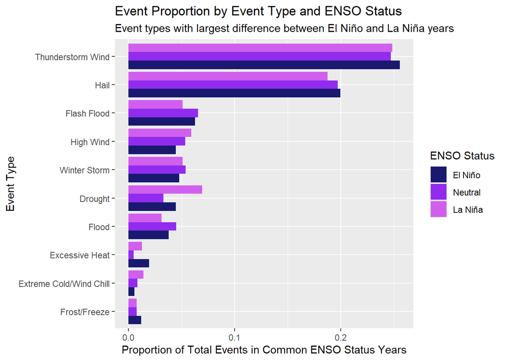

## Change in ENSO Statuses Over Time

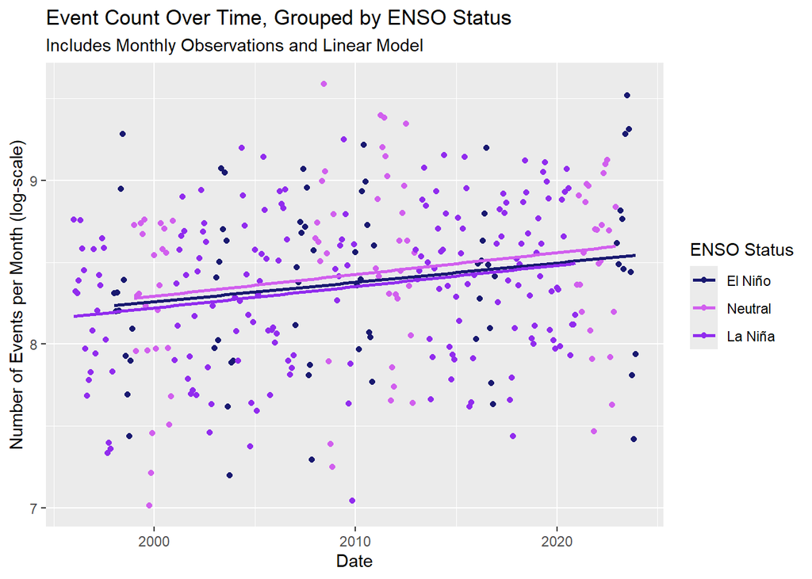

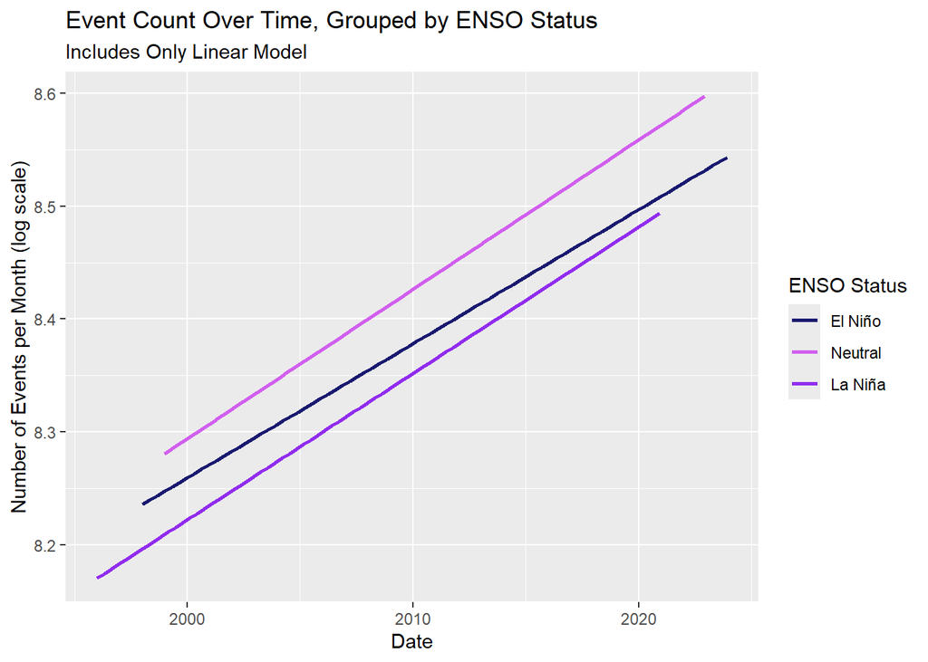

To test if this difference in slope is statistically significant, each linear model was bootstrapped using 1000 samples. The full procedure is below. The results of the bootstrapping procedure including confidence intervals were then plotted. No significant difference is apparent due to the overlap in confidence intervals, though this could be due to sample size.

```r
#calculate number of events per month for each ENSO status
#store in seperate tibbles
by_month_en <- details_enso %>%
  filter(enso_status == 'el_nino') %>%
  group_by(en_floor_date = floor_date(begin_dt, 'month')) %>%
  summarise(n = n(), enso_status = unique(enso_status))

by_month_ln <- details_enso %>%
  filter(enso_status == 'la_nina') %>%
  group_by(ln_floor_date = floor_date(begin_dt, 'month')) %>%
  summarise(n = n(), enso_status = unique(enso_status))

by_month_n <- details_enso %>%
  filter(enso_status == 'neutral') %>%
  group_by(n_floor_date = floor_date(begin_dt, 'month')) %>%
  summarise(n = n(), enso_status = unique(enso_status))

#create bootstrapping function
bootstrapping <- function(df, floor_name){
  # set a seed
  set.seed(30305)
  floor_name <- sym(floor_name)

  # take 1000 bootstrap samples
  enso_boot <- bootstraps(df, times = 1000)

  # for each sample
  # fit a model and save output in model column
  # tidy model output and save in coef_info column
  enso_slope_models <- enso_boot %>%
    mutate(
      model = map(splits, ~ lm(n ~ !!floor_name, data = .)),
      coef_info = map(model, tidy)
    )

  # un-nest coef_info (for intercept and slope)
  enso_coefs <- enso_slope_models %>%
    unnest(coef_info)

  # calculate 95% confidence interval
  int_pctl(enso_slope_models, coef_info)
}

#display bootstrapped slopes in a tibble
el_nino_slope <- bootstrapping(by_month_en, 'en_floor_date')
el_nino_slope %>% kable()
```

| term | .lower | .estimate | .upper | .alpha | .method |
| --- | --- | --- | --- | --- | --- |
| (Intercept) | -776.5484280 | 2514.2629333 | 5766.1264777 | 0.05 | percentile |
| en_floor_date | -0.0000007 | 0.0000019 | 0.0000046 | 0.05 | percentile |

```r
la_nina_slope <- bootstrapping(by_month_ln, 'ln_floor_date')
la_nina_slope %>% kable()
```

| term | .lower | .estimate | .upper | .alpha | .method |
| --- | --- | --- | --- | --- | --- |
| (Intercept) | 804.3669703 | 3047.8530145 | 5.27967e+03 | 0.05 | percentile |
| ln_floor_date | 0.0000001 | 0.0000017 | 3.50000e-06 | 0.05 | percentile |

```r
neutral_slope <- bootstrapping(by_month_n, 'n_floor_date')
neutral_slope %>% kable()
```

| term | .lower | .estimate | .upper | .alpha | .method |
| --- | --- | --- | --- | --- | --- |
| (Intercept) | 1131.8254606 | 2427.6787839 | 3690.8023971 | 0.05 | percentile |
| n_floor_date | 0.0000008 | 0.0000018 | 0.0000028 | 0.05 | percentile |

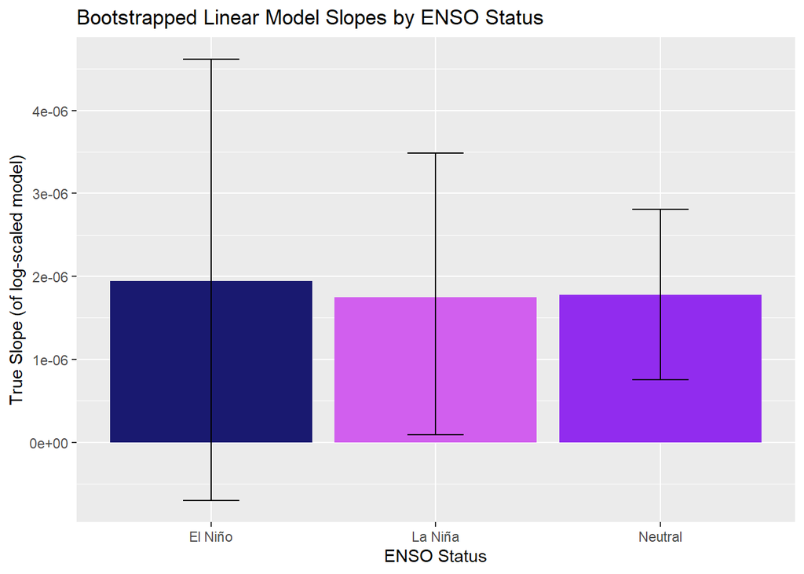

# Fatalities and Storm Events

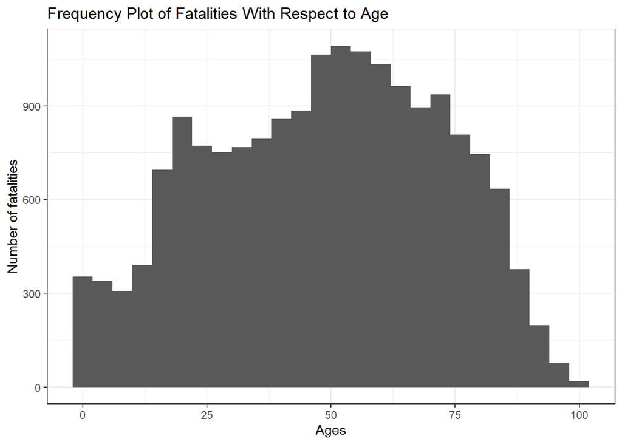

Regarding the `fatalities` dataset, we were interested in groups that appeared to be underrepresented. We chose those aged 0-13 and 70+ as the groups of interest. To simplify the analysis, we separated our weather events into more general categories.

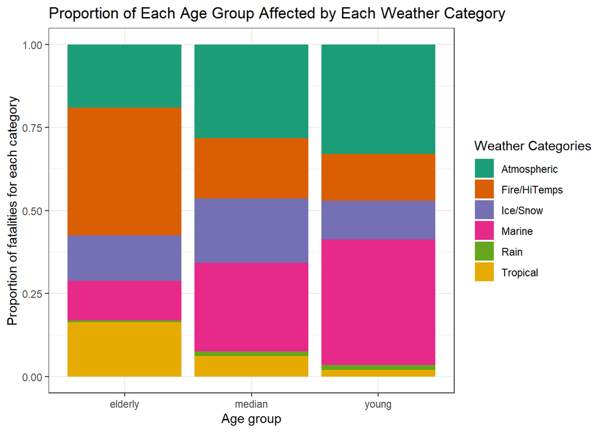

This allows us to see how different age groups are disproportionately affected by different types of weather, giving us a better understanding of who is most vulnerable to storm events. For example, we can see that both `Fire/HiTemps` and `Tropical` events are most dangerous for the elderly group, while `Atmospheric` and `Marine` events are most dangerous for younger individuals.

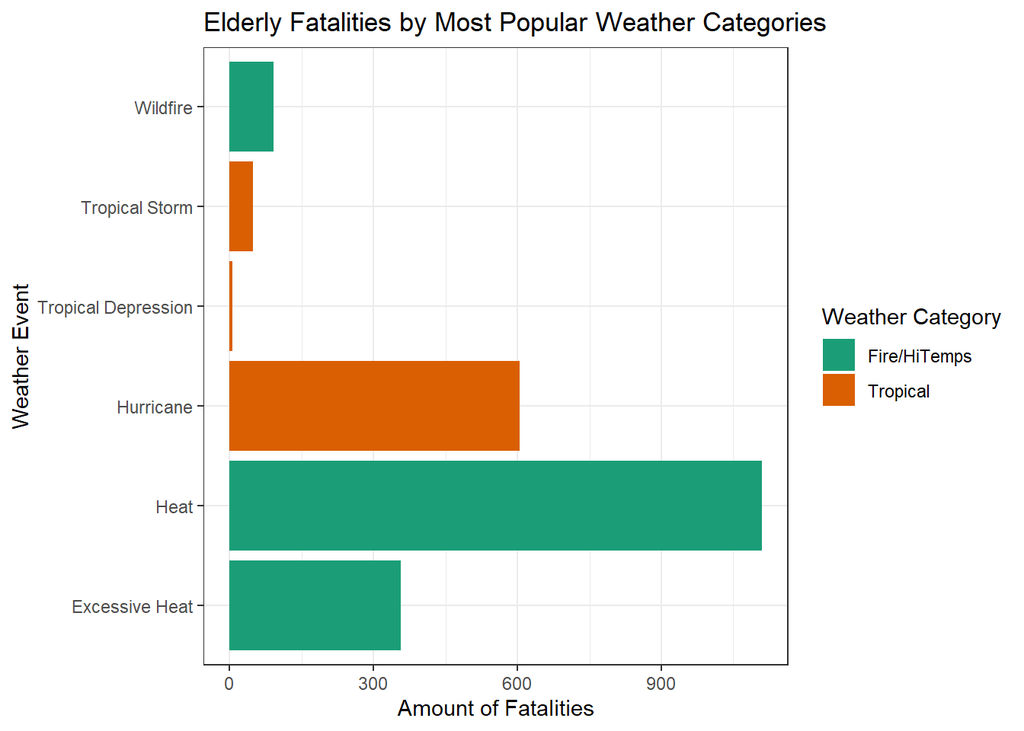

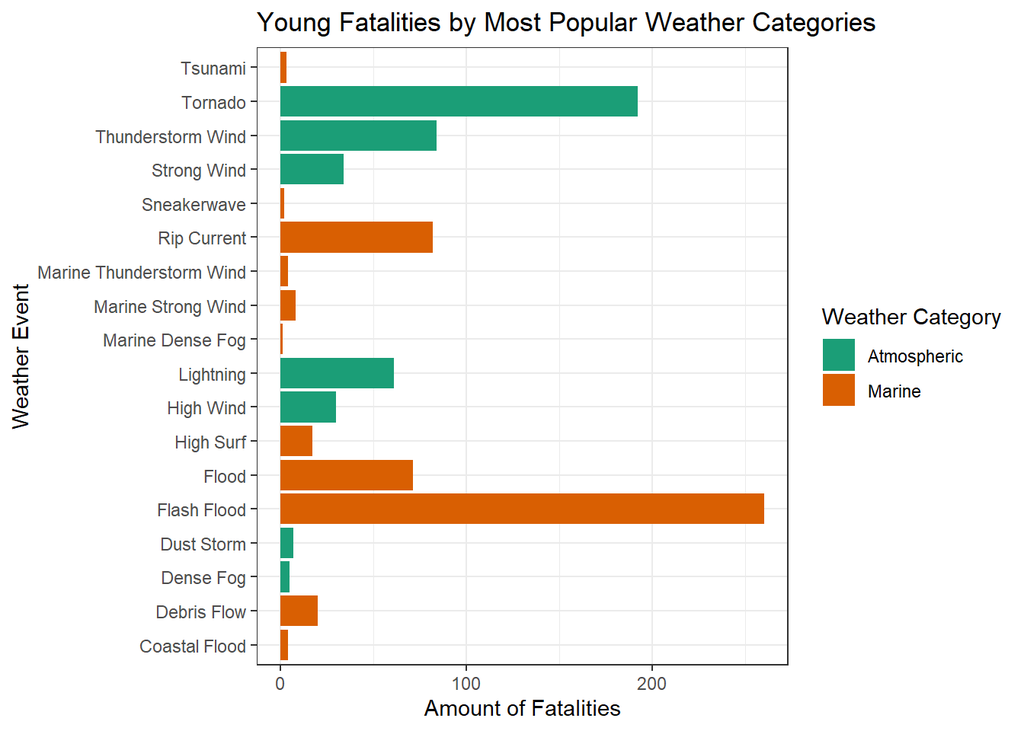

Specifically, we found that the younger age group is most affected by floods and tornadoes, whilst the elderly group is most affected by heat and hurricanes.

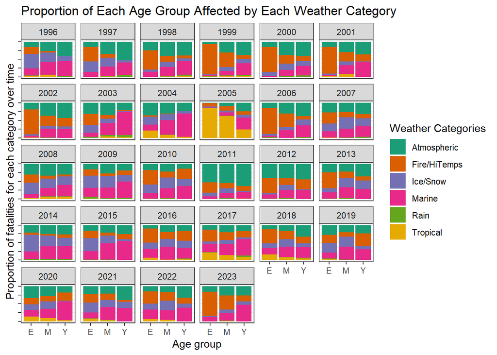

We can also see how these proportions have changed over the years of recorded data, and even note that in years of extraordinary weather (such as Hurricane Katrina in 2005 and a set of major tornadoes in 2011), weather events will disproportionately affect different age groups.

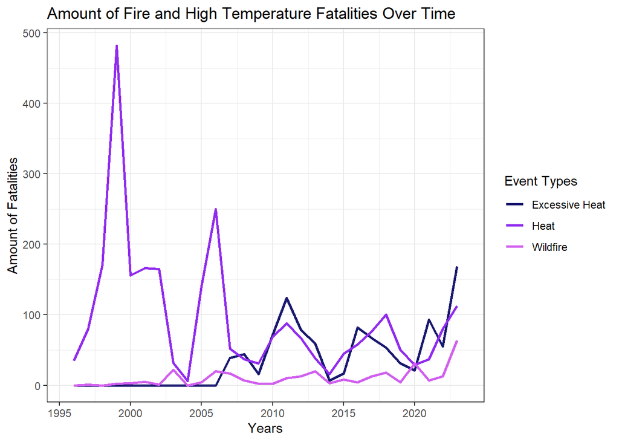

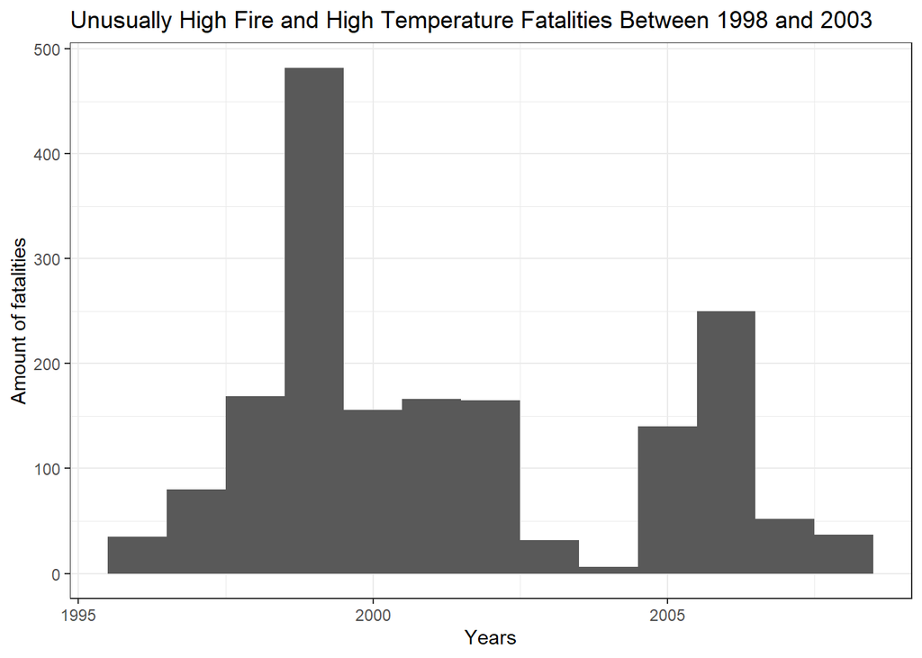

We also found that, over the past 20 years, the fatalities resulting from `Fire/HiTemps` has increased. This could possibly be the result of climate change impacting weather in the United States.

## References

Anderson, E.C. (n.d.). *Making Maps With R · Reproducible Research.* [online] eriqande.github.io. Available at: https://eriqande.github.io/rep-res-web/lectures/making-maps-with-R.html [Accessed Nov. 2024].

NASA Jet Propulsion Lab– California Institute of Technology (2024). *El Niño 2023 | El Niño/La Niña Watch & PDO*. [online] Ocean Surface Topography from Space. Available at: https://sealevel.jpl.nasa.gov/data/el-nino-la-nina-watch-and-pdo/el-nino-2023/ [Accessed Nov. 2024].

National Oceanic and Atmospheric Administration (2023). *Past Events*. [online] Noaa.gov. Available at: https://psl.noaa.gov/enso/past_events.html [Accessed Nov. 2024].

NOAA Weather service, provided data for the project, accessed at URL: https://www.ncdc.noaa.gov/stormevents/faq.jsp NOAA Weather service, data format guide, accessed at URL: https://www.ncei.noaa.gov/pub/data/swdi/stormevents/csvfiles/Storm-Data-Bulk-csv-Format.pdf